# Practical 2 - Autocovariance, Autocorrelation, Distance Autocovariance and Distance Autocorrelation

**Course:** Forecasting with Applications in Business (S411031)  
**Semester:** Fall 2026

```r
library(ggplot2)
library(energy)

set.seed(123)

manual_acf <- function(y) {
  n <- length(y)
  lags <- 0:(n - 1)
  y_bar <- mean(y)
  gamma_hat <- sapply(lags, function(h) {
    sum((y[1:(n - h)] - y_bar) * (y[(h + 1):n] - y_bar)) / n
  })
  data.frame(lag = lags, autocovariance = gamma_hat,
             autocorrelation = gamma_hat / gamma_hat[1])
}

empirical_dacf <- function(y) {
  n <- length(y)
  sapply(0:(n - 1), function(h) dcor(y[1:(n - h)], y[(h + 1):n]))
}

dcor_gaussian <- function(rho) {
  dcor_squared <- (
    rho * asin(rho) + sqrt(1 - rho^2) - rho * asin(rho / 2) -
      sqrt(4 - rho^2) + 1
  ) / (1 + pi / 3 - sqrt(3))
  sqrt(pmax(dcor_squared, 0))
}

plot_series <- function(y, title) {
  ggplot(data.frame(time = seq_along(y), value = y), aes(time, value)) +
    geom_line(colour = "#2C7FB8", linewidth = 0.4) +
    geom_hline(yintercept = 0, linetype = "dashed", colour = "red") +
    labs(title = title, x = "Time", y = expression(Y[t])) +
    theme_minimal()
}

plot_comparison <- function(data, empirical, theoretical, y_label, title) {
  ggplot(data, aes(x = lag)) +
    geom_segment(aes(xend = lag, y = 0, yend = .data[[empirical]]),
                 colour = "#2C7FB8") +
    geom_point(aes(y = .data[[theoretical]]), colour = "#D7301F", size = 2) +
    labs(title = title, x = "Lag", y = y_label) +
    theme_minimal()
}
```

## Exercise 1

> Note that Theorem 7 in Székely, Rizzo, and Bakirov (2007) implies that whenever $\rho = 0$, also $\mathcal{R}(X,Y) = 0$. However, in the lecture we discussed that the reason to use $\mathcal{R}(X,Y)$ is that it can be larger than zero even if $\rho = 0$, and can therefore detect dependencies that $\rho$ misses. How do we solve this contradiction?

### Answer

Theorem 7 applies when $X$ and $Y$ are jointly Gaussian. In this case, zero correlation implies independence, so distance correlation is also zero. For general random variables, zero correlation does not imply independence; distance correlation can therefore be positive when ordinary correlation is zero.

### Mathematical example

Theorem 7:

for *theorem 7* to hold $X$ and $Y$ must be jointly Gaussian.

meaning that:
$$\begin{pmatrix} X \\ Y
\end{pmatrix}
\sim
\mathcal{N}\left(
\begin{pmatrix} 0 \\ 0 \end{pmatrix},
\begin{pmatrix} 1 & \rho \\ \rho & 1 \end{pmatrix}
\right)$$

now let’s set that $Y=X^2$. Notice that $Y$ is not normally distributed, so $X$ and $Y$ are not jointly Gaussian.

we can calculate $Cov(X,Y)$:
$$Cov(X,Y)=\mathbb{E}[(X-\mathbb{E}[X])(Y-\mathbb{E}[Y])]$$

substitute for $Y=X^2$:
$$\Leftrightarrow
Cov(X,Y)=\mathbb{E}[(X-\mathbb{E}[X])(X^2-\mathbb{E}[X^2])]$$

since $X \sim \mathcal{N}(0,1)$, we know $\mathbb{E}[X]=0$, $\mathbb{E}[X^2]=1$, and $\mathbb{E}[X^3]=0$:
$$\Leftrightarrow
Cov(X,Y)=\mathbb{E}[(X-0)(X^2-1)]$$

compute:
$$\Leftrightarrow
Cov(X,Y)=\mathbb{E}[X^3-X]$$

separate expectations:
$$\Leftrightarrow
Cov(X,Y)=\mathbb{E}[X^3]-\mathbb{E}[X]$$

take expectations:
$$\Leftrightarrow
Cov(X,Y)=0-0=0$$

$$\rho(X,Y)=\frac{\gamma(X,Y)}{\sqrt{\gamma(X,X)\gamma(Y,Y)}}$$

where $\gamma(X,Y)=Cov(X,Y)$.

we can conclude that:
$$\rho(X,Y)=0$$

However, $Y=X^2$ is fully determined by $X$, so $X$ and $Y$ are dependent. Theorem 7 does not apply because $X$ and $Y$ are not jointly Gaussian.

Since $Y=X^2$ is a non-constant deterministic function of $X$, $X$ and $Y$ are dependent. Distance correlation satisfies

$$\mathcal{R}(X,Y)=0
\quad \Longleftrightarrow \quad
X \text{ and } Y \text{ are independent}.$$

Therefore, since $X$ and $Y$ are dependent,

$$\mathcal{R}(X,Y)>0.$$

## Exercise 2 - Autocovariance and autocorrelation of white noise

### Model

$$Y_t \overset{\text{i.i.d.}}{\sim}
\mathcal{N}(0, 5^2), \qquad n = 500.$$

### 2.1 Simulate the process

> Simulate a white noise process $Y_t \overset{\text{i.i.d.}}{\sim} \mathcal{N}(0, 5^2)$ of length $n = 500$.

```r
n <- 500
sigma <- 5
y_wn <- rnorm(n, mean = 0, sd = sigma)
```

### 2.2 Plot the generated time series

> Plot the generated time series.

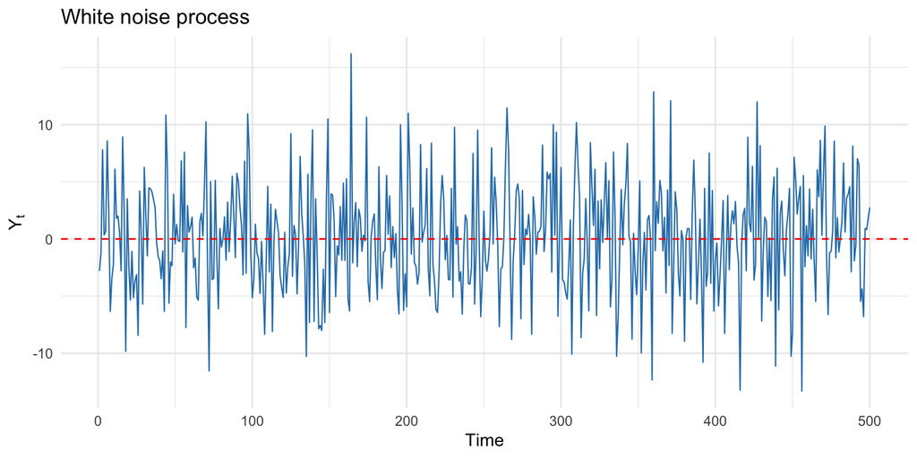

```r
plot_series(y_wn, "White noise process")
```

The series fluctuates around zero and does not show a visible time pattern.

### 2.3 Compute empirical autocovariance and autocorrelation

> Compute the empirical autocovariance $\hat{\gamma}(h)$ and autocorrelation $\hat{\rho}(h)$ for lags $h = 0, 1, \ldots, n - 1$, manually and using the R function `acf()`.

```r
wn_manual <- manual_acf(y_wn)
wn_acf <- acf(y_wn, type = "correlation", lag.max = n - 1, plot = FALSE)
wn_acov <- acf(y_wn, type = "covariance", lag.max = n - 1, plot = FALSE)

wn_results <- transform(
  wn_manual,
  autocorrelation_acf = as.numeric(wn_acf$acf),
  autocovariance_acf = as.numeric(wn_acov$acf)
)

all.equal(wn_results$autocorrelation, wn_results$autocorrelation_acf)
```

```
## [1] TRUE
```

```r
all.equal(wn_results$autocovariance, wn_results$autocovariance_acf)
```

```
## [1] TRUE
```

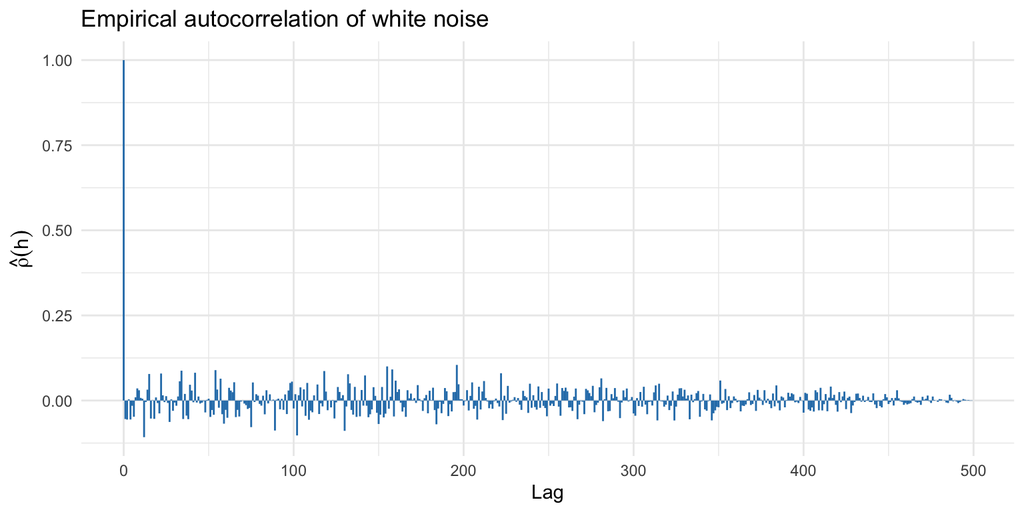

```r
ggplot(wn_results, aes(lag, autocorrelation)) +
  geom_segment(aes(xend = lag, y = 0, yend = autocorrelation), colour = "#2C7FB8") +
  labs(title = "Empirical autocorrelation of white noise",
       x = "Lag", y = expression(hat(rho)(h))) +
  theme_minimal()
```

The manual estimates and `acf()` give the same result. Apart from lag zero, the sample autocorrelations fluctuate around zero.

### 2.4 Derive the theoretical functions

> Derive the theoretical autocovariance and autocorrelation function of the process.

### Derivation

```r
wn_results$autocovariance_theoretical <- ifelse(wn_results$lag == 0, sigma^2, 0)
wn_results$autocorrelation_theoretical <- ifelse(wn_results$lag == 0, 1, 0)
```

### 2.5 Compare autocorrelation and distance autocorrelation

> Compare the empirical and theoretical autocorrelation and distance autocorrelation. *Hint: Use Theorem 7 in Székely, Rizzo, and Bakirov (2007) to compute the theoretical distance autocorrelation.*

### Comparison notes

```r
wn_results$distance_autocorrelation <- empirical_dacf(y_wn)
wn_results$distance_autocorrelation_theoretical <-
  dcor_gaussian(wn_results$autocorrelation_theoretical)
```

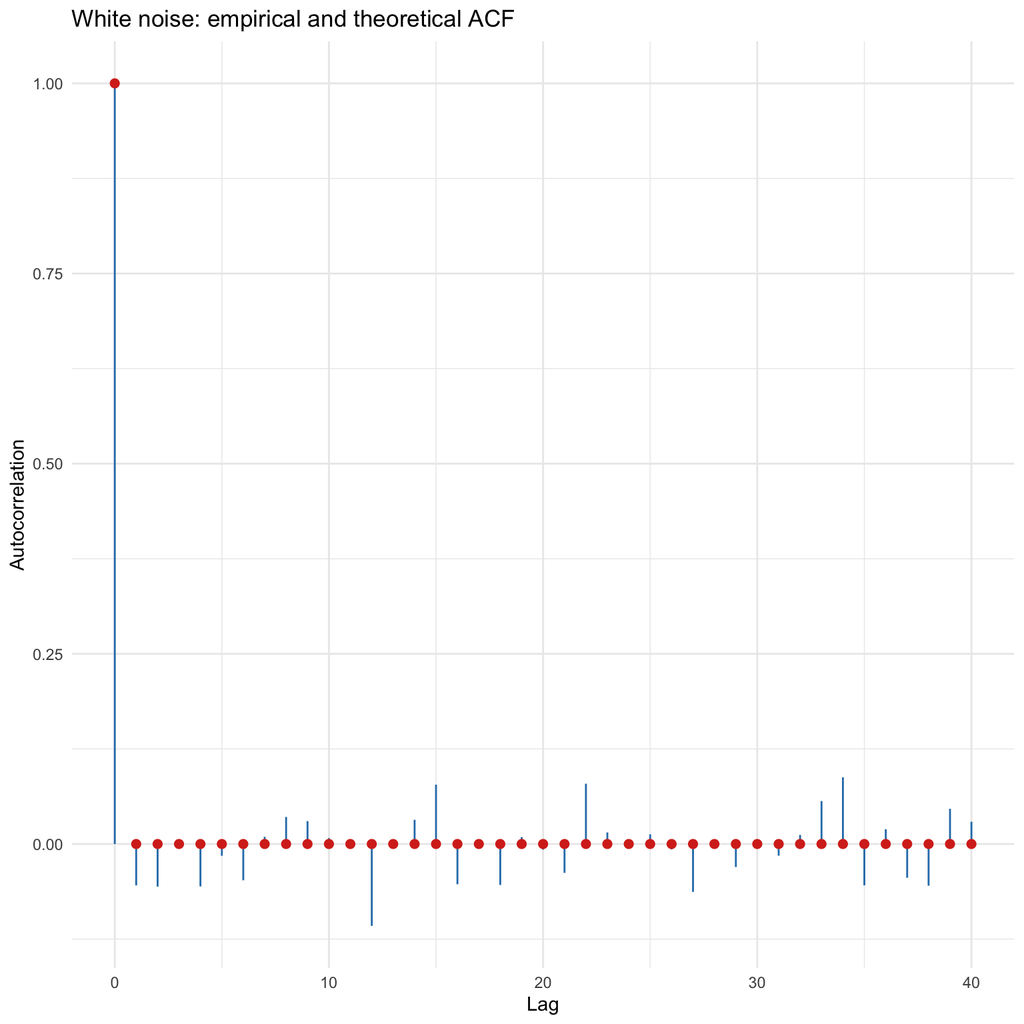

```r
wn_short <- subset(wn_results, lag <= 40)

plot_comparison(wn_short, "autocorrelation", "autocorrelation_theoretical",
                "Autocorrelation", "White noise: empirical and theoretical ACF")
```

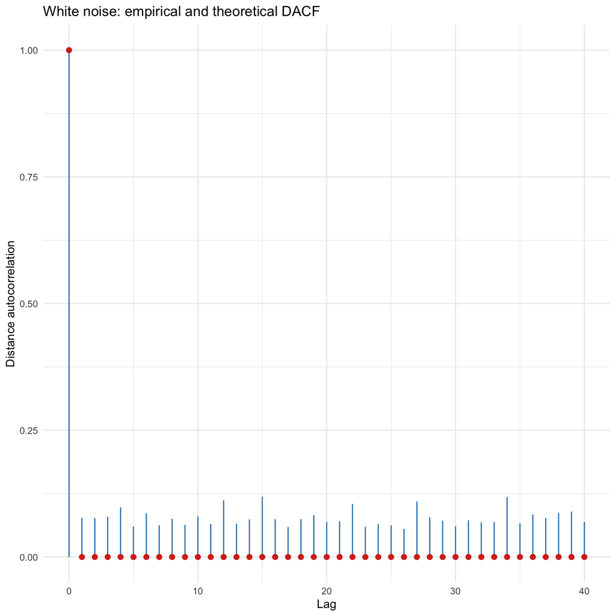

```r
plot_comparison(wn_short, "distance_autocorrelation", "distance_autocorrelation_theoretical",
                "Distance autocorrelation", "White noise: empirical and theoretical DACF")
```

The theoretical ACF and DACF are zero for all positive lags. The empirical values are not exactly zero because they are calculated from a finite sample.

## Exercise 3 - Autocovariance and autocorrelation of an AR(1) process

### Model

$$Y_t = 0.7Y_{t-1} + \varepsilon_t, \qquad
\varepsilon_t \sim \mathcal{N}(0, 2^2), \qquad n = 500.$$

### 3.1 Simulate a trajectory

> Simulate a trajectory of length $n = 500$.

```r
phi <- 0.7
sigma_e <- 2
y_ar1 <- as.numeric(arima.sim(model = list(ar = phi), n = n, sd = sigma_e))
```

### 3.2 Plot the generated time series

> Plot the generated time series.

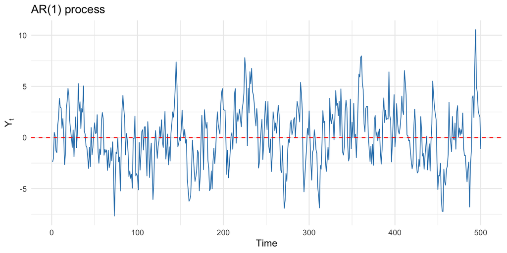

```r
plot_series(y_ar1, "AR(1) process")
```

The series shows persistence: consecutive observations tend to move together.

### 3.3 Compute empirical autocovariance and autocorrelation

> Compute the empirical autocovariance $\hat{\gamma}(h)$ and autocorrelation $\hat{\rho}(h)$ for lags $h = 0, 1, \ldots, n - 1$, manually and using the R function `acf()`.

```r
ar1_manual <- manual_acf(y_ar1)
ar1_acf <- acf(y_ar1, type = "correlation", lag.max = n - 1, plot = FALSE)
ar1_acov <- acf(y_ar1, type = "covariance", lag.max = n - 1, plot = FALSE)

ar1_results <- transform(
  ar1_manual,
  autocorrelation_acf = as.numeric(ar1_acf$acf),
  autocovariance_acf = as.numeric(ar1_acov$acf)
)

all.equal(ar1_results$autocorrelation, ar1_results$autocorrelation_acf)
```

```
## [1] TRUE
```

```r
all.equal(ar1_results$autocovariance, ar1_results$autocovariance_acf)
```

```
## [1] TRUE
```

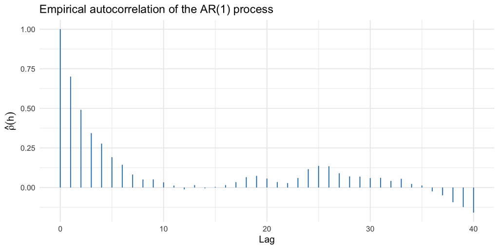

```r
ggplot(subset(ar1_results, lag <= 40), aes(lag, autocorrelation)) +
  geom_segment(aes(xend = lag, y = 0, yend = autocorrelation), colour = "#2C7FB8") +
  labs(title = "Empirical autocorrelation of the AR(1) process",
       x = "Lag", y = expression(hat(rho)(h))) +
  theme_minimal()
```

The manual estimates and `acf()` agree. The empirical ACF decreases gradually as the lag increases.

### 3.4 Derive the theoretical functions

> Derive the theoretical autocovariance and autocorrelation function of the process.

### Derivation

```r
ar1_results$autocovariance_theoretical <-
  (sigma_e^2 / (1 - phi^2)) * phi^ar1_results$lag
ar1_results$autocorrelation_theoretical <- phi^ar1_results$lag
```

### 3.5 Compare autocorrelation and distance autocorrelation

> Compare the empirical and theoretical autocorrelation and distance autocorrelation. *Hint: Use Theorem 7 in Székely, Rizzo, and Bakirov (2007) to compute the theoretical distance autocorrelation.*

### Comparison notes

```r
ar1_results$distance_autocorrelation <- empirical_dacf(y_ar1)
ar1_results$distance_autocorrelation_theoretical <-
  dcor_gaussian(ar1_results$autocorrelation_theoretical)
```

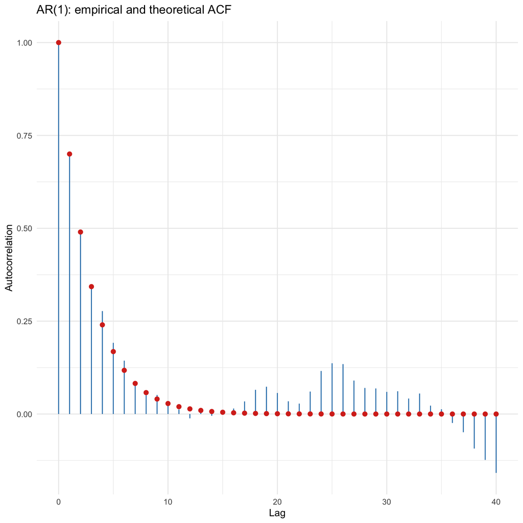

```r
ar1_short <- subset(ar1_results, lag <= 40)

plot_comparison(ar1_short, "autocorrelation", "autocorrelation_theoretical",
                "Autocorrelation", "AR(1): empirical and theoretical ACF")
```

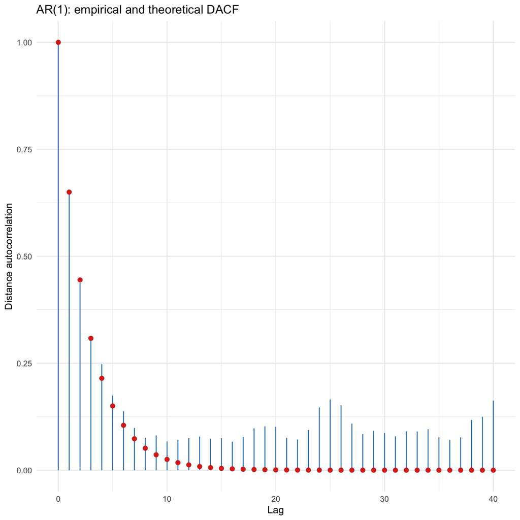

```r
plot_comparison(ar1_short, "distance_autocorrelation", "distance_autocorrelation_theoretical",
                "Distance autocorrelation", "AR(1): empirical and theoretical DACF")
```

Both empirical measures decay towards zero with the lag. Small differences from the theoretical curves are due to simulation variability.

## Exercise 4 - Autocovariance and autocorrelation of an MA(1) process

### Model

$$Y_t = \varepsilon_t +
0.5\varepsilon_{t-1}, \qquad \varepsilon_t \sim \mathcal{N}(0, 2^2),
\qquad n = 500.$$

### 4.1 Simulate a trajectory

> Simulate a trajectory of length $n = 500$.

```r
theta <- 0.5
sigma_e <- 2
y_ma1 <- as.numeric(arima.sim(model = list(ma = theta), n = n, sd = sigma_e))
```

### 4.2 Plot the generated time series

> Plot the generated time series.

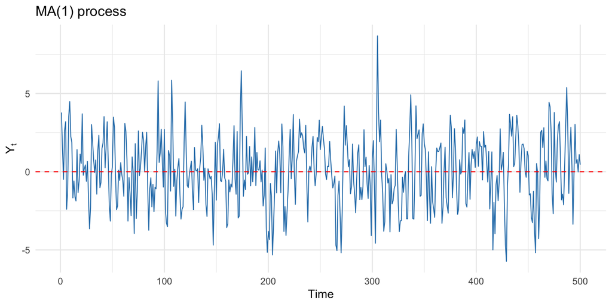

```r
plot_series(y_ma1, "MA(1) process")
```

The series has short-term dependence because neighbouring observations share one innovation.

### 4.3 Compute empirical autocovariance and autocorrelation

> Compute the empirical autocovariance $\hat{\gamma}(h)$ and autocorrelation $\hat{\rho}(h)$ for lags $h = 0, 1, \ldots, n - 1$, manually and using the R function `acf()`.

```r
ma1_manual <- manual_acf(y_ma1)
ma1_acf <- acf(y_ma1, type = "correlation", lag.max = n - 1, plot = FALSE)
ma1_acov <- acf(y_ma1, type = "covariance", lag.max = n - 1, plot = FALSE)

ma1_results <- transform(
  ma1_manual,
  autocorrelation_acf = as.numeric(ma1_acf$acf),
  autocovariance_acf = as.numeric(ma1_acov$acf)
)

all.equal(ma1_results$autocorrelation, ma1_results$autocorrelation_acf)
```

```
## [1] TRUE
```

```r
all.equal(ma1_results$autocovariance, ma1_results$autocovariance_acf)
```

```
## [1] TRUE
```

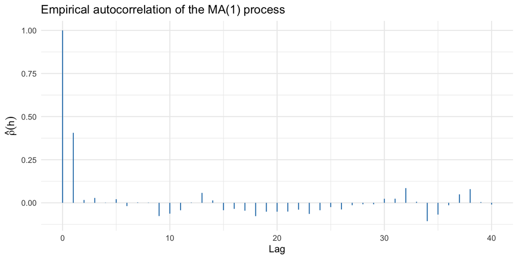

```r
ggplot(subset(ma1_results, lag <= 40), aes(lag, autocorrelation)) +
  geom_segment(aes(xend = lag, y = 0, yend = autocorrelation), colour = "#2C7FB8") +
  labs(title = "Empirical autocorrelation of the MA(1) process",
       x = "Lag", y = expression(hat(rho)(h))) +
  theme_minimal()
```

The manual estimates and `acf()` agree. The main dependence is at lag one; later sample correlations fluctuate around zero.

### 4.4 Derive the theoretical functions

> Derive the theoretical autocovariance and autocorrelation function of the process.

### Derivation

```r
ma1_results$autocovariance_theoretical <- ifelse(
  ma1_results$lag == 0,
  sigma_e^2 * (1 + theta^2),
  ifelse(ma1_results$lag == 1, sigma_e^2 * theta, 0)
)

ma1_results$autocorrelation_theoretical <- ifelse(
  ma1_results$lag == 0,
  1,
  ifelse(ma1_results$lag == 1, theta / (1 + theta^2), 0)
)
```

### 4.5 Compare autocorrelation and distance autocorrelation

> Compare the empirical and theoretical autocorrelation and distance autocorrelation. *Hint: Use Theorem 7 in Székely, Rizzo, and Bakirov (2007) to compute the theoretical distance autocorrelation.*

### Comparison notes

```r
ma1_results$distance_autocorrelation <- empirical_dacf(y_ma1)
ma1_results$distance_autocorrelation_theoretical <-
  dcor_gaussian(ma1_results$autocorrelation_theoretical)
```

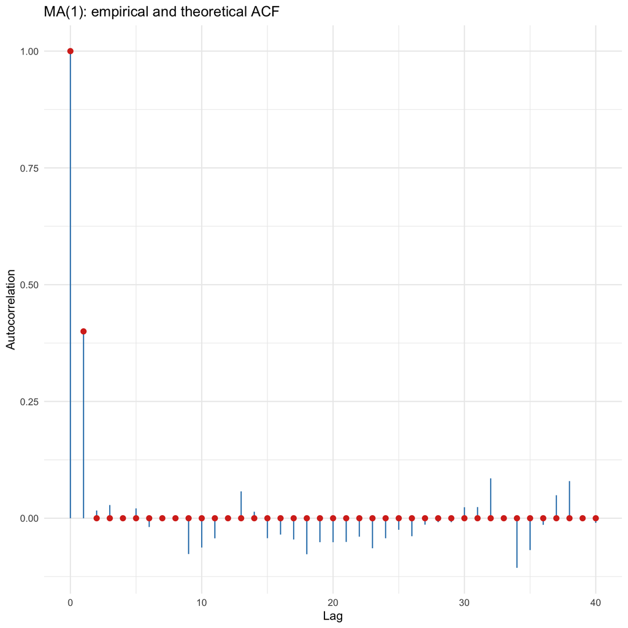

```r
ma1_short <- subset(ma1_results, lag <= 40)

plot_comparison(ma1_short, "autocorrelation", "autocorrelation_theoretical",
                "Autocorrelation", "MA(1): empirical and theoretical ACF")
```

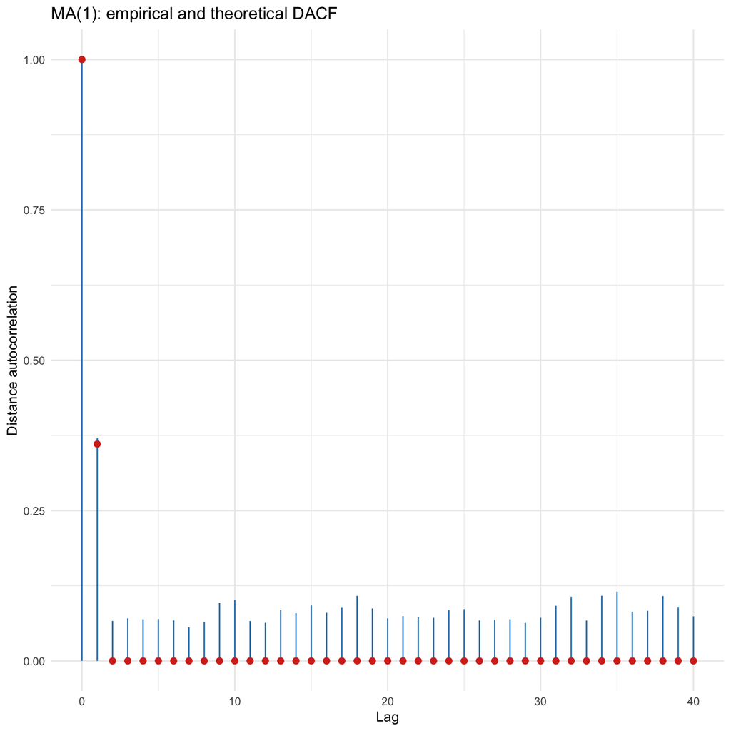

```r
plot_comparison(ma1_short, "distance_autocorrelation", "distance_autocorrelation_theoretical",
                "Distance autocorrelation", "MA(1): empirical and theoretical DACF")
```

The theoretical ACF and DACF are non-zero at lag one only. The empirical estimates show small values at later lags because the sample is finite.

## Reference from the assignment

Székely, Gábor J., Maria L. Rizzo, and Nail K. Bakirov (2007). “Measuring and Testing Dependence by Correlation of Distances.” *The Annals of Statistics*, 35(6), 2769-2794.